Skip to main content

# Block 4 – FLUXNET Data Summary

Author

Timo Sanzol Rieth

Published

November 14, 2026

## Setup

```r
packages <- c("here", "sf", "rnaturalearth", "tidyverse")

missing <- packages[!packages %in% installed.packages()[, "Package"]]
if (length(missing) > 0) install.packages(missing)

invisible(lapply(packages, library, character.only = TRUE))
```

## Read zip files, load data

```r
# Spalten, die behalten werden sollen
keep <- c("TIMESTAMP_START", "TIMESTAMP_END", "TA_F", "SW_IN_F", "VPD_F", "P_F",
          "NETRAD", "G_F_MDS", "H_F_MDS", "H_F_MDS_QC", "LE_F_MDS", "LE_F_MDS_QC",
          "NEE_VUT_REF", "NEE_VUT_REF_QC", "GPP_NT_VUT_REF", "RECO_NT_VUT_REF")

# Liest die Halbstunden-Daten aus EINER FLUXNET-ZIP-Datei
read_fluxnet_hh <- function(zip_file, keep, exdir = here("data", "raw", "unzipped")) {
  site_id <- regmatches(basename(zip_file),
                        regexpr("[A-Z]{2}-[A-Za-z0-9]{3}", basename(zip_file)))
  hh_name <- grep("FLUXMET_HH", unzip(zip_file, list = TRUE)$Name, value = TRUE)
  unzip(zip_file, files = hh_name, exdir = exdir)

  read_csv(file.path(exdir, hh_name),
           na = "-9999",
           col_select = any_of(keep),
           col_types = cols(TIMESTAMP_START = "c", TIMESTAMP_END = "c", .default = "d")) |>
    mutate(time = as.POSIXct(TIMESTAMP_START, format = "%Y%m%d%H%M", tz = "UTC"),
           site = site_id,
           .before = 1)
}

zip_files <- list.files(here("data", "raw"), pattern = "\\.zip$", full.names = TRUE)
hh <- lapply(zip_files, read_fluxnet_hh, keep = keep) |> bind_rows()

count(hh, site)
```

```
# A tibble: 5 × 2
  site        n
  <chr>   <int>
1 AU-Whr 262992
2 CN-Xi2 175344
3 CZ-wet 350640
4 IT-SR2 227904
5 US-Mo3 140256
```

## Section 1: Site overview

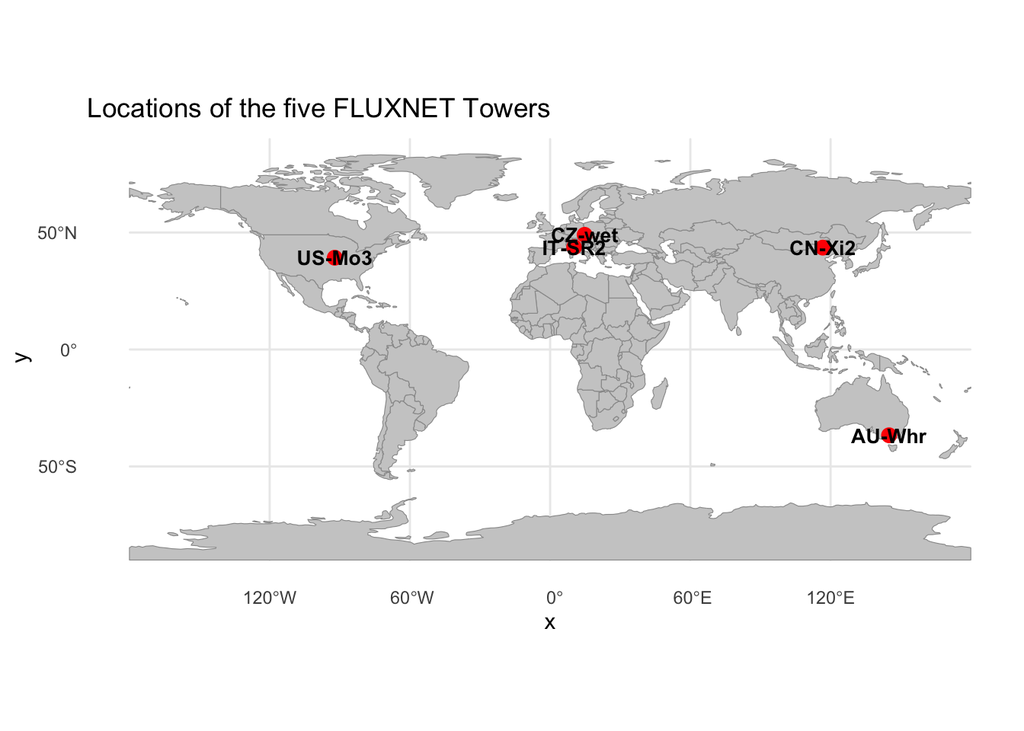

```r
#1. load snapshot-file

snap_file <- list.files(here("data", "snapshots"),
                        pattern = "^fluxnet_shuttle_snapshot_.*\\.csv$",
                        full.names = TRUE) |> sort() |> tail(1)

snap <- read_csv(snap_file, show_col_types = FALSE)

#create table with information on towers

tower_table <- snap %>%
  filter(site_id %in% hh$site) %>%
  select(
    Site_ID = site_id,
    name = site_name,
    IGBP = igbp,
    latitude = location_lat,
    longitude = location_long,
    first_year = first_year,
    last_year = last_year,
    hub = data_hub,
    citation = product_citation
  ) %>%
  mutate(country = substr(Site_ID, 1,2))



#map of tower sites

world <- ne_countries(scale ="small", returnclass = "sf")

towers_sf <- st_as_sf(tower_table,
                      coords = c("longitude", "latitude"),
                      crs = 4326)

ggplot()+
  geom_sf(data = world, fill = "grey80", color = "grey60", linewidth = 0.2) +
  geom_sf(data = towers_sf, color = "red", size = 3) +
  geom_sf_text(data = towers_sf, aes(label = Site_ID), size = 3.5, fontface = "bold") +
  labs(title = "Locations of the five FLUXNET Towers") +
  theme_minimal()
```

## Section 2: Data availability

```r
data_avail <- hh %>%
  mutate(year = as.integer(format(time, "%Y"))) %>%
  group_by(site, year) %>%
  summarise(
    n_halfhours = n(),
    share_measured = mean(coalesce(NEE_VUT_REF_QC == 0, FALSE)),
    .groups = "drop"
  )

#top 10 site-year combinations with most available data
data_avail %>% arrange(desc(share_measured)) %>% head(10)
```

```
# A tibble: 10 × 4
   site    year n_halfhours share_measured
   <chr>  <int>       <int>          <dbl>
 1 US-Mo3  2020       17568          0.608
 2 US-Mo3  2017       17520          0.606
 3 US-Mo3  2019       17520          0.590
 4 CZ-wet  2020       17568          0.582
 5 US-Mo3  2022       17520          0.580
 6 US-Mo3  2021       17520          0.572
 7 CZ-wet  2023       17520          0.565
 8 US-Mo3  2023       17520          0.563
 9 CZ-wet  2019       17520          0.563
10 CZ-wet  2024       17568          0.558
```

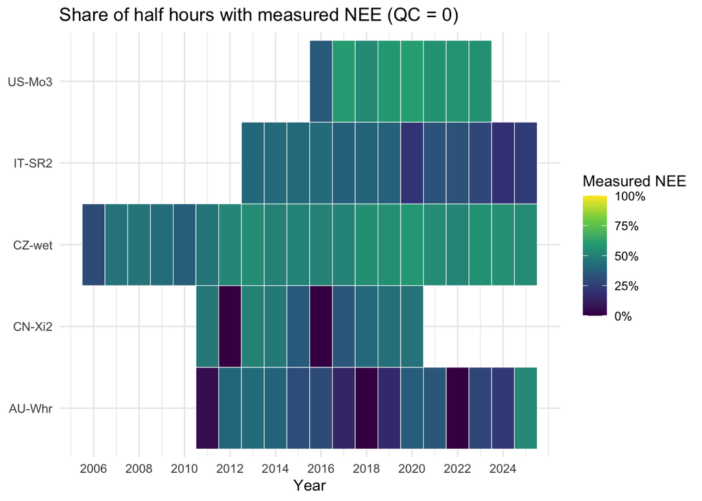

```r
#heat map

ggplot(data = data_avail, aes(x = year, y = site, fill = share_measured)) +
  geom_tile(colour = "white") +
  scale_fill_viridis_c(limits = c(0,1),
                       labels = scales::percent,
                       name = "Measured NEE") +
  scale_x_continuous(breaks = seq(min(data_avail$year), max(data_avail$year), by = 2)) +
  labs(x = "Year", y = NULL,
       title = "Share of half hours with measured NEE (QC = 0)") +
  theme_minimal()
```

Result: Us-Mo3 has the shortest but best covered NEE Measurements. The best year is 2020.

## Section 3: Data summary

```r
vars <- c("TA_F", "SW_IN_F", "VPD_F", "P_F", "NEE_VUT_REF",
          "GPP_NT_VUT_REF", "RECO_NT_VUT_REF", "H_F_MDS", "LE_F_MDS")

units <- c(
  TA_F            = "°C",
  SW_IN_F         = "W m-2",
  VPD_F           = "hPa",
  P_F             = "mm; Mittel = mittl. Jahressumme mm a-1",
  NEE_VUT_REF     = "gC m-2 d-1",
  GPP_NT_VUT_REF  = "gC m-2 d-1",
  RECO_NT_VUT_REF = "gC m-2 d-1",
  H_F_MDS         = "W m-2",
  LE_F_MDS        = "W m-2"
)


hh <- hh %>%
  mutate(year = year(time))


#define function to crate table with basic statistics

make_table <- function(d){
  tab <- d %>%
    summarise(across(all_of(vars), list(
      mean    = ~ mean(.x, na.rm = TRUE),
      min     = ~ min(.x, na.rm = TRUE),
      max     = ~ max(.x, na.rm = TRUE),
      missing = ~ mean(is.na(.x)) * 100
    ))) %>%
    pivot_longer(everything(),
                 names_to = c("variable", "stat"),
                 names_pattern = "(.*)_(mean|min|max|missing)$") %>%
    pivot_wider(names_from = variable, values_from = value)



#Precipitation
p_annual <- d %>%
  group_by(year) %>%
  summarise(
    p_sum = sum(P_F, na.rm=T)) %>%
  pull(p_sum) %>%
  mean()

tab$P_F[tab$stat == "mean"] <- p_annual

#add units to values
tab %>%
  rename_with(~ paste0(.x, " [", units[.x], "]"), all_of(vars)) %>%
  mutate(across(where(is.numeric), ~ round(.x, 2)))


}


#one table per site:
site_tables <- lapply(split(hh, hh$site), make_table)

site_tables$`US-Mo3`
```

```
# A tibble: 4 × 10
  stat    `TA_F [°C]` `SW_IN_F [W m-2]` `VPD_F [hPa]` P_F [mm; Mittel = mittl.…¹
  <chr>         <dbl>             <dbl>         <dbl>                      <dbl>
1 mean           13.1              179.          5.84                      946
2 min           -24.0                0           0                           0
3 max            38.6             1137.         45.9                        41.7
4 missing         0                  0           0                           0
# ℹ abbreviated name: ¹`P_F [mm; Mittel = mittl. Jahressumme mm a-1]`
# ℹ 5 more variables: `NEE_VUT_REF [gC m-2 d-1]` <dbl>,
#   `GPP_NT_VUT_REF [gC m-2 d-1]` <dbl>, `RECO_NT_VUT_REF [gC m-2 d-1]` <dbl>,
#   `H_F_MDS [W m-2]` <dbl>, `LE_F_MDS [W m-2]` <dbl>
```

```r
site_tables$`IT-SR2`
```

```
# A tibble: 4 × 10
  stat    `TA_F [°C]` `SW_IN_F [W m-2]` `VPD_F [hPa]` P_F [mm; Mittel = mittl.…¹
  <chr>         <dbl>             <dbl>         <dbl>                      <dbl>
1 mean          15.8               177.          4.71                     1068.
2 min           -5.46                0           0                           0
3 max           35.3              1111.         40.5                        35.9
4 missing        0                   0           0                           0
# ℹ abbreviated name: ¹`P_F [mm; Mittel = mittl. Jahressumme mm a-1]`
# ℹ 5 more variables: `NEE_VUT_REF [gC m-2 d-1]` <dbl>,
#   `GPP_NT_VUT_REF [gC m-2 d-1]` <dbl>, `RECO_NT_VUT_REF [gC m-2 d-1]` <dbl>,
#   `H_F_MDS [W m-2]` <dbl>, `LE_F_MDS [W m-2]` <dbl>
```

```r
site_tables$`CZ-wet`
```

```
# A tibble: 4 × 10
  stat    `TA_F [°C]` `SW_IN_F [W m-2]` `VPD_F [hPa]` P_F [mm; Mittel = mittl.…¹
  <chr>         <dbl>             <dbl>         <dbl>                      <dbl>
1 mean           8.84              135.          3.23                      582.
2 min          -25.7                 0           0                           0
3 max           36.1              1035.         43.6                        44.4
4 missing        0                   0           0                           0
# ℹ abbreviated name: ¹`P_F [mm; Mittel = mittl. Jahressumme mm a-1]`
# ℹ 5 more variables: `NEE_VUT_REF [gC m-2 d-1]` <dbl>,
#   `GPP_NT_VUT_REF [gC m-2 d-1]` <dbl>, `RECO_NT_VUT_REF [gC m-2 d-1]` <dbl>,
#   `H_F_MDS [W m-2]` <dbl>, `LE_F_MDS [W m-2]` <dbl>
```

```r
site_tables$`CN-Xi2`
```

```
# A tibble: 4 × 10
  stat    `TA_F [°C]` `SW_IN_F [W m-2]` `VPD_F [hPa]` P_F [mm; Mittel = mittl.…¹
  <chr>         <dbl>             <dbl>         <dbl>                      <dbl>
1 mean           1.68              193.          5.36                      285.
2 min          -37.7                 0           0                           0
3 max           37.4              1153.         56.4                        19.8
4 missing        0                   0           0                           0
# ℹ abbreviated name: ¹`P_F [mm; Mittel = mittl. Jahressumme mm a-1]`
# ℹ 5 more variables: `NEE_VUT_REF [gC m-2 d-1]` <dbl>,
#   `GPP_NT_VUT_REF [gC m-2 d-1]` <dbl>, `RECO_NT_VUT_REF [gC m-2 d-1]` <dbl>,
#   `H_F_MDS [W m-2]` <dbl>, `LE_F_MDS [W m-2]` <dbl>
```

```r
site_tables$`AU-Whr`
```

```
# A tibble: 4 × 10
  stat    `TA_F [°C]` `SW_IN_F [W m-2]` `VPD_F [hPa]` P_F [mm; Mittel = mittl.…¹
  <chr>         <dbl>             <dbl>         <dbl>                      <dbl>
1 mean           15.4              192.           7.5                      313.
2 min          -240.                 0            0                          0
3 max            43.8             1184           81.4                       13.8
4 missing         0                  0            0                          0
# ℹ abbreviated name: ¹`P_F [mm; Mittel = mittl. Jahressumme mm a-1]`
# ℹ 5 more variables: `NEE_VUT_REF [gC m-2 d-1]` <dbl>,
#   `GPP_NT_VUT_REF [gC m-2 d-1]` <dbl>, `RECO_NT_VUT_REF [gC m-2 d-1]` <dbl>,
#   `H_F_MDS [W m-2]` <dbl>, `LE_F_MDS [W m-2]` <dbl>
```

## Section 4: Time series

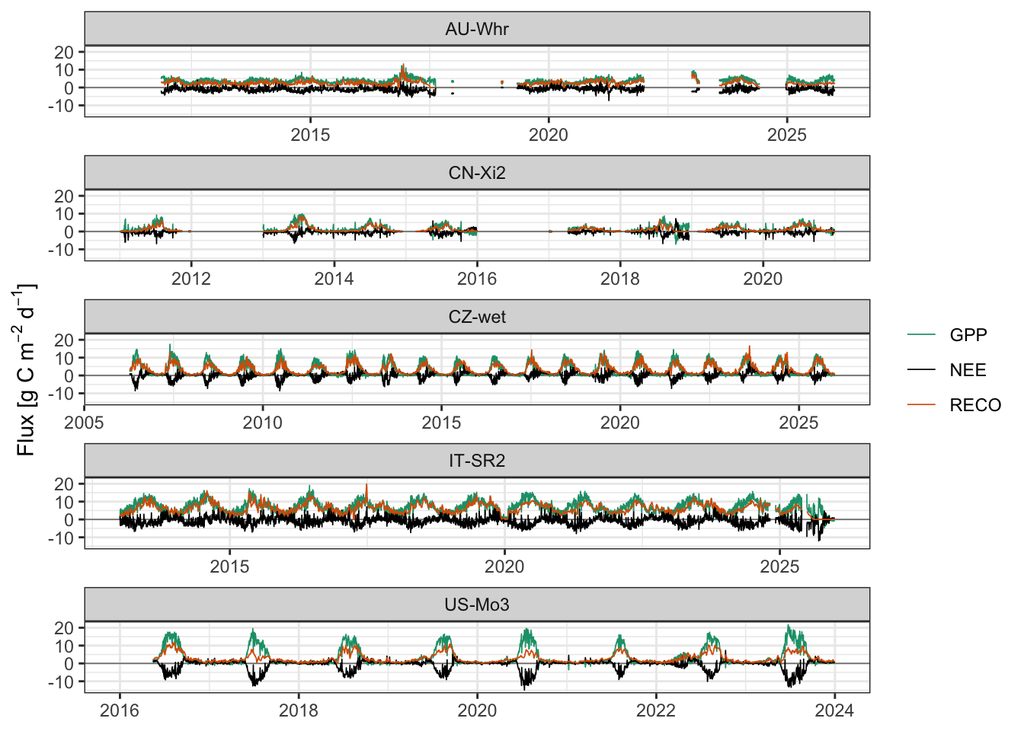

```r
flux_vars <- c("NEE_VUT_REF", "GPP_NT_VUT_REF", "RECO_NT_VUT_REF")

daily <- hh %>%
  mutate(date = as.Date(time)) %>%
  group_by(site, date) %>%
  summarise(
    n_valid = sum(!is.na(NEE_VUT_REF)),               # number valid half-hours
    across(all_of(flux_vars), ~ mean(.x, na.rm = TRUE) * 1.0378),
    .groups = "drop"
  ) %>%
  mutate(across(all_of(flux_vars), ~ if_else(is.nan(.x), NA_real_, .x)))

daily_long <- daily %>%
  pivot_longer(all_of(flux_vars), names_to = "flux", values_to = "value") %>%
  mutate(flux = recode(flux,
                       NEE_VUT_REF     = "NEE",
                       GPP_NT_VUT_REF  = "GPP",
                       RECO_NT_VUT_REF = "RECO"))

ggplot(daily_long, aes(x = date, y = value, colour = flux)) +
  geom_hline(yintercept = 0, linewidth = 0.3, colour = "grey50") +
  geom_line(linewidth = 0.3) +
  facet_wrap(~ site, ncol = 1, scales = "free_x") +
  scale_colour_manual(values = c(NEE = "black", GPP = "#1b9e77", RECO = "#d95f02")) +
  labs(x = NULL,
       y = expression("Flux [g C m"^-2*" d"^-1*"]"),
       colour = NULL) +
  theme_bw()
```

## Section 5: Diurnal cycles

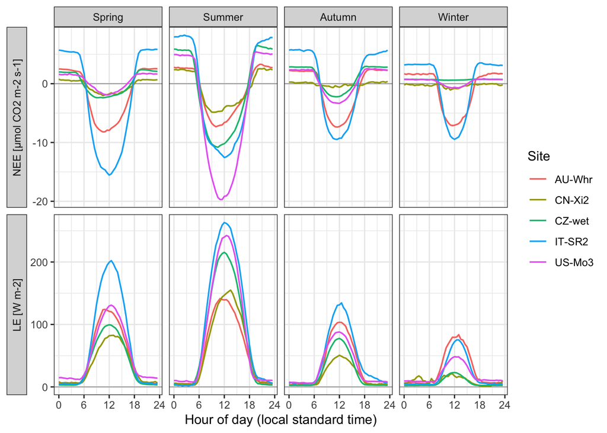

```r
site_lat <- tower_table %>%
  select(site = Site_ID, lat = latitude) %>%
  filter(site %in% unique(hh$site))


diurnal <- hh %>%
  left_join(site_lat, by = "site") %>%
  mutate(
    month     = month(time),
    # southern hemisphere: shift month by 6
    month_adj = if_else(lat < 0, (month + 5) %% 12 + 1, month),
    season    = case_when(
      month_adj %in% c(12, 1, 2) ~ "Winter",
      month_adj %in% 3:5         ~ "Spring",
      month_adj %in% 6:8         ~ "Summer",
      month_adj %in% 9:11        ~ "Autumn"
    ),
    season = factor(season, levels = c("Spring", "Summer", "Autumn", "Winter")),
    hour   = hour(time) + minute(time) / 60      # 0, 0.5, 1, ..., 23.5
  )

diurnal_mean <- diurnal %>%
  group_by(site, season, hour) %>%
  summarise(
    NEE = mean(NEE_VUT_REF, na.rm = TRUE),
    LE  = mean(LE_F_MDS,   na.rm = TRUE),
    .groups = "drop"
  ) %>%
  pivot_longer(c(NEE, LE), names_to = "variable", values_to = "value") %>%
  mutate(variable = factor(variable,
                           levels = c("NEE", "LE"),
                           labels = c("NEE [µmol CO2 m-2 s-1]", "LE [W m-2]")))

ggplot(diurnal_mean, aes(x = hour, y = value, colour = site)) +
  geom_hline(yintercept = 0, colour = "grey60", linewidth = 0.3) +
  geom_line(linewidth = 0.6) +
  facet_grid(variable ~ season, scales = "free_y", switch = "y") +
  scale_x_continuous(breaks = seq(0, 24, 6)) +
  labs(x = "Hour of day (local standard time)", y = NULL, colour = "Site") +
  theme_bw() +
  theme(strip.placement = "outside")
```

Seasons were defined as meteorological seasons based on calendar months (Spring: MAM, Summer: JJA, Autumn: SON, Winter: DJF for the northern hemisphere). For sites in the southern hemisphere (latitude < 0°), months were shifted by six months before assigning seasons, so that e.g. January is classified as summer and July as winter. The mean diurnal course was computed by averaging all half-hourly values per site, season and time of day.

## Section 6: Your reading

```r
hh %>%
  group_by(site) %>%
  summarise(NETRAD = mean(!is.na(NETRAD)) * 100,
            G      = mean(!is.na(G_F_MDS)) * 100)
```

```
# A tibble: 5 × 3
  site   NETRAD     G
  <chr>   <dbl> <dbl>
1 AU-Whr   65.9  19.9
2 CN-Xi2   75.2  80.9
3 CZ-wet   89.6  70.7
4 IT-SR2   35.9  90.4
5 US-Mo3   91.4  95.9
```

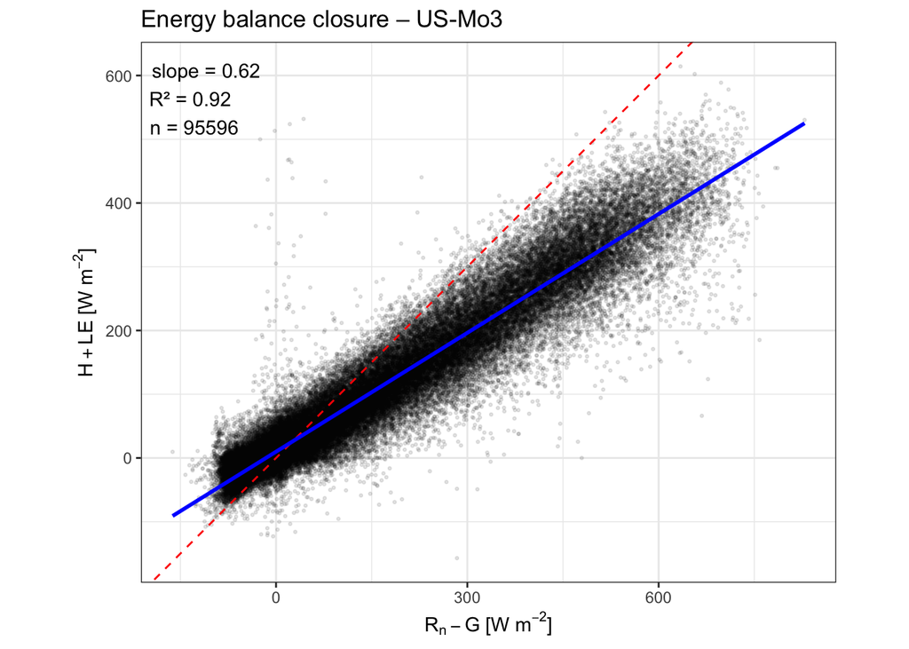

```r
eb_site <- "US-Mo3"

eb <- hh %>%
  filter(site == eb_site,
         H_F_MDS_QC == 0,          # nur gemessene H-Werte
         LE_F_MDS_QC == 0) %>%     # nur gemessene LE-Werte
  mutate(turb  = H_F_MDS + LE_F_MDS,
         avail = NETRAD - G_F_MDS) %>%
  filter(!is.na(turb), !is.na(avail))

fit   <- lm(turb ~ avail, data = eb)
slope <- coef(fit)[["avail"]]
r2    <- summary(fit)$r.squared

ggplot(eb, aes(x = avail, y = turb)) +
  geom_point(alpha = 0.1, size = 0.5) +
  geom_abline(slope = 1, intercept = 0, colour = "red", linetype = "dashed") +
  geom_smooth(method = "lm", se = FALSE, colour = "blue") +
  annotate("text", x = -Inf, y = Inf, hjust = -0.1, vjust = 1.3,
           label = sprintf("slope = %.2f\nR² = %.2f\nn = %d", slope, r2, nrow(eb))) +
  coord_equal() +
  labs(x = expression(R[n] - G ~ "[W m"^-2*"]"),
       y = expression(H + LE ~ "[W m"^-2*"]"),
       title = paste("Energy balance closure –", eb_site)) +
  theme_bw()
```

```r
annual <- daily %>%
  mutate(year = year(date)) %>%
  group_by(site, year) %>%
  summarise(n_days = sum(!is.na(NEE_VUT_REF)),
            across(all_of(flux_vars), ~ sum(.x, na.rm = TRUE)),
            .groups = "drop") %>%
  filter(n_days >= 360) %>%
  group_by(site) %>%
  summarise(n_years = n(),
            across(all_of(flux_vars), mean))   # mittlere Jahressumme in g C m-2 a-1

annual %>% arrange(NEE_VUT_REF)
```

```
# A tibble: 5 × 5
  site   n_years NEE_VUT_REF GPP_NT_VUT_REF RECO_NT_VUT_REF
  <chr>    <int>       <dbl>          <dbl>           <dbl>
1 AU-Whr       8      -370.           1326.            931.
2 US-Mo3       7      -307.           1274.            967.
3 IT-SR2      11      -250.           2618.           2368.
4 CN-Xi2       2      -153.            707.            564.
5 CZ-wet      19        80.2          1139.           1218.
```

```r
seasonal <- daily %>%
  mutate(month = month(date)) %>%
  group_by(site, month) %>%
  summarise(NEE = mean(NEE_VUT_REF, na.rm = TRUE),
            GPP = mean(GPP_NT_VUT_REF, na.rm = TRUE), .groups = "drop") %>%
  group_by(site) %>%
  summarise(amp_NEE = max(NEE) - min(NEE),
            amp_GPP = max(GPP) - min(GPP))
```

```r
gapfill <- hh %>%
  group_by(site) %>%
  summarise(across(c(NEE_VUT_REF_QC, H_F_MDS_QC, LE_F_MDS_QC),
                   ~ mean(.x > 0, na.rm = TRUE) * 100))
```

Averaged over all complete years, AU-Whr is the strongest carbon sink with a mean annual NEE of −370 g C m⁻² a⁻¹, followed by US-Mo3 (−307 g C m⁻² a⁻¹) and IT-SR2 (−250 g C m⁻² a⁻¹). IT-SR2 has by far the largest gross fluxes (GPP ≈ 2620, RECO ≈ 2370 g C m⁻² a⁻¹), roughly twice those of the other sites, but because respiration offsets most of the uptake, its net sink is only intermediate. The largest seasonal cycle is found at US-Mo3, where the monthly mean NEE varies by 7.1 g C m⁻² d⁻¹ (GPP: 11.8 g C m⁻² d⁻¹), whereas AU-Whr shows the smallest amplitude (1.4 g C m⁻² d⁻¹) despite being the strongest annual sink, indicating that its uptake is spread fairly evenly throughout the year. The most surprising result is CZ-wet, which acts as a net carbon source (+80 g C m⁻² a⁻¹ over 19 years) because ecosystem respiration exceeds GPP, although wetlands are often expected to accumulate carbon. The result for CN-Xi2 (−153 g C m⁻² a⁻¹) should be treated with caution, as it is based on only two complete years. A large share of the data is gap-filled: between 42 % (US-Mo3) and 66 % (IT-SR2) of the half-hourly NEE values, compared with 13–27 % for H and 22–38 % for LE. The higher gap fraction for NEE mainly reflects the additional filtering of night-time periods with low turbulence (u* filtering). Annual carbon budgets therefore depend strongly on the gap-filling algorithm and carry considerable uncertainty.

## Citation

- **AU-Whr**: Beringer, J., Arndt, S., Loew, M., Hinko-Najera, N. (2026): Whroo FLUXNET Release 2026_r1. Version 2026_r1. Terrestrial Ecosystem Research Network (TERN). (Dataset).
- **CN-Xi2**: Chen, S. (2026). Fluxnet Archive Product from Xilinhot grassland site (X03), 2011–2020, FLUXNET, https://hdl.handle.net/11676/Q9e9OH0qQmaJV4OiVUDW3BAV
- **CZ-wet**: Dusek, J., Kivalov, S., Pavelka, M., Šigut, L., Jocher, G., Czerný, R., Staník, K., Stellner, S., Trusina, J. (2026). Fluxnet Archive Product from Trebon, 2006–2025, FLUXNET, https://hdl.handle.net/11676/ezclJdsSs31JZaOdM4gbLbIn
- **IT-SR2**: Arriga, N., Goded, I., Grüning, C., Dell’Acqua, A., Matteucci, M. (2026). Fluxnet Archive Product from San Rossore 2, 2013–2025, FLUXNET, https://hdl.handle.net/11676/xmKHyUZQfcLwolbWA7E2YEYg
- **US-Mo3**: Adam Schreiner-McGraw (2026), AmeriFlux FLUXNET-1F US-Mo3 LTAR CMRB Field 3 (CMRB BAU), Ver. v1.3_r1 (2016-2023), AmeriFlux AMP, (Dataset). https://doi.org/10.17190/AMF/2229384